# Naples Reef (Jan 2010) Purple Urchins

Eli Schulman

10/24/2021

Overview: The code wrangles then visualizes data on Urchins (Purple and Red) in the Santa Barbara county. Exploratory graphs (histogram and Q-Q plot) are used to visualize urchin distributions. Summary statistics regarding Purple Urchins at Naples Reef are shown.

*Data Citation:* Reed, D. 2020. SBC LTER: Reef: Long-term experiment: Kelp removal: Urchin size frequency distribution ver 20. Environmental Data Initiative. https://doi.org/10.6073/pasta/5a1e9ef03aa47bd2225c0bb98a02a63b.

## Setup - attach packages

```r
knitr::opts_chunk$set(echo = TRUE, message = FALSE, warning = FALSE)

# attach packages
library(tidyverse)
library(here)
library(janitor)
library(kableExtra)
library(lubridate)
```

## Exract data for Purple Urchins at Naples Reef in 2010

```r
urchins_purp <- read_csv(here("data", "urchins.csv")) %>%
  clean_names() %>%
# convert date column using lubridate, then create a year variable
  mutate(date = mdy(date)) %>%
  mutate(year = year(date)) %>%
# filter for Naples, purple urchins, and 2010 data
  filter(common_name == "Purple Urchin",
         site == 'NAPL',
         year == 2010)
```

## Urchin Treatment Sampling

### Exploratory Graphics

Histogram and Q-Q Plots

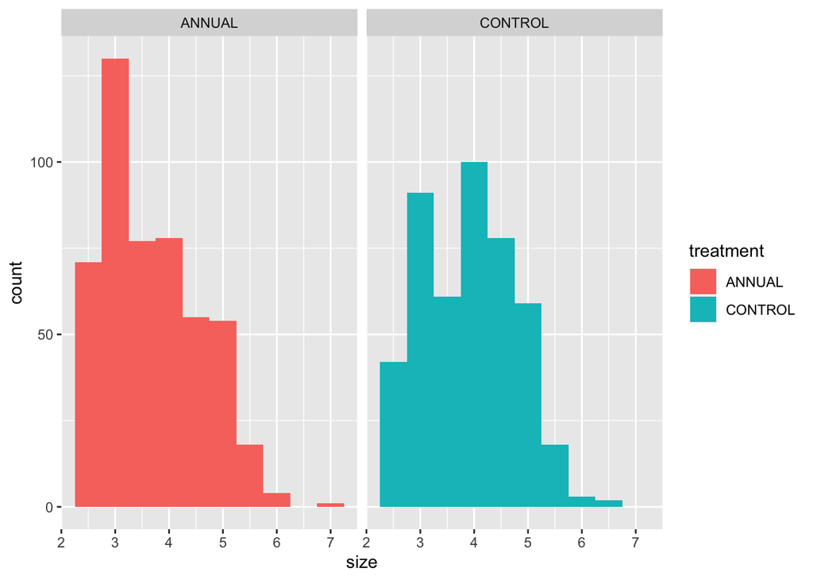

```r
# histogram of purple urchins to show distribution of sizes at naples between control and annual groups
ggplot(urchins_purp, aes(x = size)) +
  geom_histogram(aes(fill = treatment), bins = 10) +
  facet_wrap(~ treatment)
```

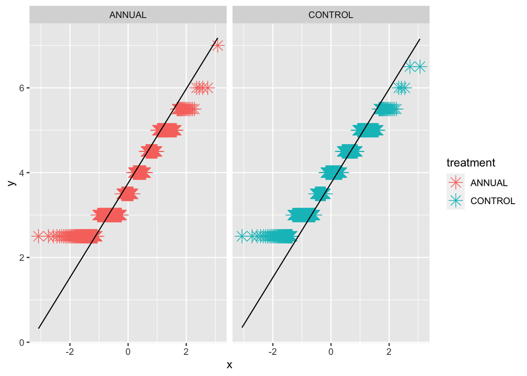

```r
# Q-Q plot to show "correlation"?????
ggplot(urchins_purp, aes(sample = size)) +
  geom_qq(aes(color = treatment), shape = 8, size = 4) +
  geom_qq_line() +
  facet_wrap(~ treatment)
```

#### Interpretation: The samples are both normally distributed, and exhibit a slight positive skew. We cannot tell, from these graphics, whether removing the giant kelp each winter (ANNUAL treatment) results in smaller purple urchins at Naples Reef.

### Purple Urchins at Naples Reef

Summary Statistics for Control Group Sample and Annual Kelp Removal Sample

```r
urchins_purp_stats <- urchins_purp %>%
# add new column with reader friendly treatment descriptions
  mutate(treatment_descr = case_when(
    treatment == "ANNUAL" ~ "Annual Kelp Removal (Each Winter)",
    TRUE ~ "Control Group (No Kelp Removal)")
    ) %>%
  group_by(treatment_descr) %>%
# create sample statistics
  summarize(sample_size = n(),
            mean = signif(mean(size), 2),
            median = signif(median(size), 2),
            min = signif(min(size), 2),
            max = signif(max(size), 2),
            sd = signif(sd(size), 2)
            )
# create a formatted kable table
kable(urchins_purp_stats,
      col.names = c('Sampling Group', 'Sample Size', 'Mean (cm)', 'Median (cm)', 'Smallest (cm)', 'Largest (cm)', 'Standard Deviation (cm)'),
      caption = 'Sample Statistics for Purple Urchins at Naples Reef') %>%
  kable_styling(full_width = FALSE) %>%
  kable_material(c("striped"))
```

Sample Statistics for Purple Urchins at Naples Reef

| Sampling Group | Sample Size | Mean (cm) | Median (cm) | Smallest (cm) | Largest (cm) | Standard Deviation (cm) |
| --- | --- | --- | --- | --- | --- | --- |
| Annual Kelp Removal (Each Winter) | 488 | 3.7 | 3.5 | 2.5 | 7.0 | 0.90 |
| Control Group (No Kelp Removal) | 454 | 3.9 | 4.0 | 2.5 | 6.5 | 0.87 |

#### Interpretation: Annual kelp removal doesn’t appear to have a significant effect on Purple Urchin sizes at the Naples Reef. The mean sampling size of urchins, given kelp removal, was .2 cm smaller than the control group. Additionaly, the standard deviation between the control group and kelp removal group differed by only .03 cm (.87 cm and .90 cm respectively).